# Advanced graphics with R_part 2

### there is more informative scatter matrix plot function in car package, lets see how it works.

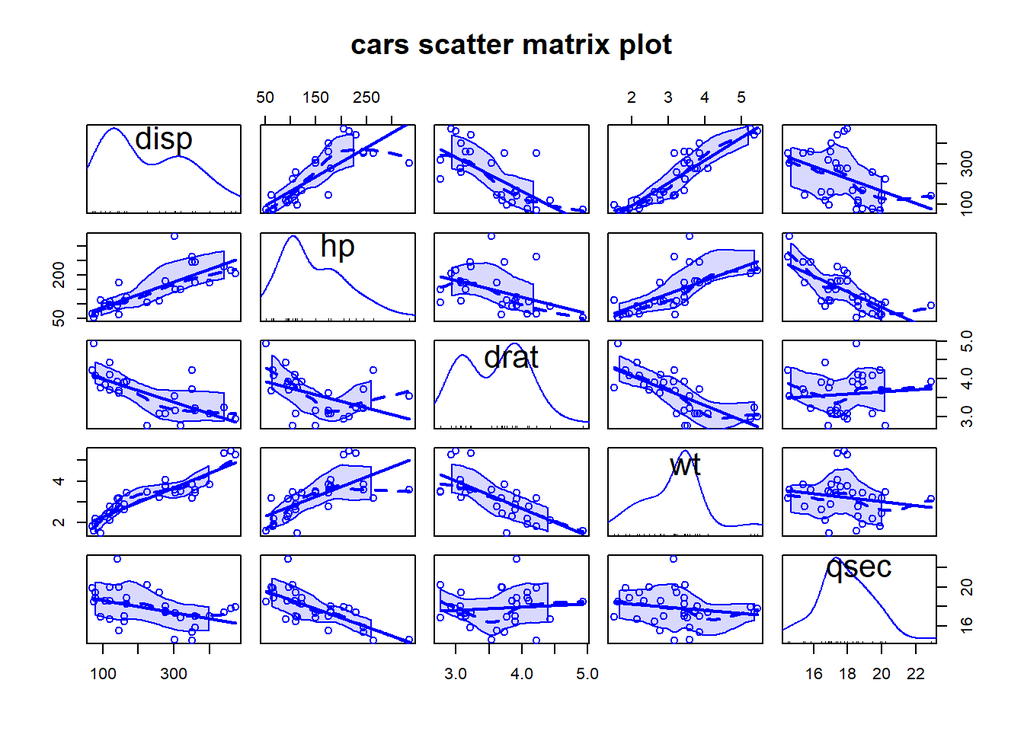

```r
scatterplotMatrix(cars, spread=FALSE, lty.smooth=2, main="cars scatter matrix plot")
```

### As you see, this plot is very useful in case of bivariate correlation to examine the relationship among variables (2 or more).

### This graph includes liner and smoothed fit and marginal distributions (Kernel density and rug plots).

> Hint: to examine the correlation

```r
cor(cars) # default is pearson, to use kendall or spearman just add method="spearman"
```

```
##            disp         hp        drat         wt        qsec
## disp  1.0000000  0.7909486 -0.71021393  0.8879799 -0.43369788
## hp    0.7909486  1.0000000 -0.44875912  0.6587479 -0.70822339
## drat -0.7102139 -0.4487591  1.00000000 -0.7124406  0.09120476
## wt    0.8879799  0.6587479 -0.71244065  1.0000000 -0.17471588
## qsec -0.4336979 -0.7082234  0.09120476 -0.1747159  1.00000000
```

```r
# Im giving another coarse for correlation and regression in a more detailed approach
```

### For me, i like the function ggpairs in (GGally package), lets see why.

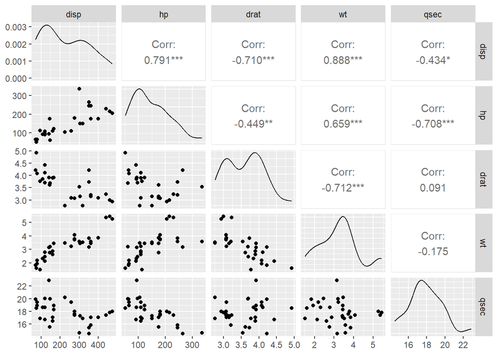

```r
ggpairs(cars)
```

### here it combines scatter plot, kernel density and correlation together.

### I hope your plotting concept now is changed to better